# STOR 455 Exam #2 Julie Bonds

```r
library(readr)
library(bestglm)
library(mosaic)
library(car)
library(Stat2Data)
library(dplyr)
library(MASS)
library(tidyverse)


ShowSubsets=function(regout){
  z=summary(regout)
  q=as.data.frame(z$outmat)
  q$Rsq=round(z$rsq*100,2)
  q$adjRsq=round(z$adjr2*100,2)
  q$Cp=round(z$cp,2)
  return(q)
}

SpeedDating = read_csv("http://mclean.web.unc.edu/files/2020/04/SpeedDating.csv")

SpeedDatingM = read_csv("http://mclean.web.unc.edu/files/2020/04/SpeedDatingM.csv")
SpeedDatingF = read_csv("http://mclean.web.unc.edu/files/2020/04/SpeedDatingF.csv")
```

#1)

```r
head(SpeedDating)
```

| DecisionM | DecisionF | LikeM | LikeF | PartnerYesM | PartnerYesF | AgeM | AgeF | RaceM | RaceF | AttractiveM | AttractiveF | SincereM | SincereF | IntelligentM | IntelligentF | FunM | FunF | AmbitiousM | AmbitiousF | SharedInterestsM | SharedInterestsF |
| --- | --- | --- | --- | --- | --- | --- | --- | --- | --- | --- | --- | --- | --- | --- | --- | --- | --- | --- | --- | --- | --- |
| 0 | 0 | 6 | 7 | 5 | 5 | 27 | 21 | 3 | 3 | 6 | 5 | 8 | 8 | 8 | 8 | 8 | 2 | 7 | 2 | 6 | 2 |
| 1 | 0 | 8 | 7 | 4 | 3 | 22 | 22 | 3 | 1 | 7 | 6 | 9 | 6 | 10 | 8 | 6 | 4 | 6 | 9 | 5 | 4 |
| 1 | 0 | 10 | 6 | 10 | 2 | 22 | 23 | 1 | 1 | 10 | 4 | 10 | 7 | 10 | 9 | 10 | 4 | 10 | 3 | 10 | 2 |
| 1 | 1 | 9 | 7 | 7 | 8 | 23 | 24 | 3 | 3 | 9 | 7 | 9 | 9 | 9 | 7 | 9 | 6 | 9 | 5 | 9 | 7 |
| 1 | 1 | 7 | 5 | 8 | 5 | 24 | 26 | 4 | 5 | 7 | 5 | 9 | 10 | 8 | 8 | 9 | 8 | 7 | 5 | 7 | 5 |
| 0 | 0 | 7 | 6 | 7 | 6 | 27 | 23 | 3 | 3 | 6 | 5 | 7 | 9 | 8 | 9 | 6 | 5 | 6 | 9 | 5 | 7 |

```r
SpeedDating$AgeDifference = (SpeedDating$AgeM-SpeedDating$AgeF)
head(SpeedDating)
```

| DecisionM | DecisionF | LikeM | LikeF | PartnerYesM | PartnerYesF | AgeM | AgeF | RaceM | RaceF | AttractiveM | AttractiveF | SincereM | SincereF | IntelligentM | IntelligentF | FunM | FunF | AmbitiousM | AmbitiousF | SharedInterestsM | SharedInterestsF | AgeDifference |
| --- | --- | --- | --- | --- | --- | --- | --- | --- | --- | --- | --- | --- | --- | --- | --- | --- | --- | --- | --- | --- | --- | --- |
| 0 | 0 | 6 | 7 | 5 | 5 | 27 | 21 | 3 | 3 | 6 | 5 | 8 | 8 | 8 | 8 | 8 | 2 | 7 | 2 | 6 | 2 | 6 |
| 1 | 0 | 8 | 7 | 4 | 3 | 22 | 22 | 3 | 1 | 7 | 6 | 9 | 6 | 10 | 8 | 6 | 4 | 6 | 9 | 5 | 4 | 0 |
| 1 | 0 | 10 | 6 | 10 | 2 | 22 | 23 | 1 | 1 | 10 | 4 | 10 | 7 | 10 | 9 | 10 | 4 | 10 | 3 | 10 | 2 | -1 |
| 1 | 1 | 9 | 7 | 7 | 8 | 23 | 24 | 3 | 3 | 9 | 7 | 9 | 9 | 9 | 7 | 9 | 6 | 9 | 5 | 9 | 7 | -1 |
| 1 | 1 | 7 | 5 | 8 | 5 | 24 | 26 | 4 | 5 | 7 | 5 | 9 | 10 | 8 | 8 | 9 | 8 | 7 | 5 | 7 | 5 | -2 |
| 0 | 0 | 7 | 6 | 7 | 6 | 27 | 23 | 3 | 3 | 6 | 5 | 7 | 9 | 8 | 9 | 6 | 5 | 6 | 9 | 5 | 7 | 4 |

```r
mod1 <- glm(DecisionM~AgeDifference, data = SpeedDating, family = "binomial")
```

#2)

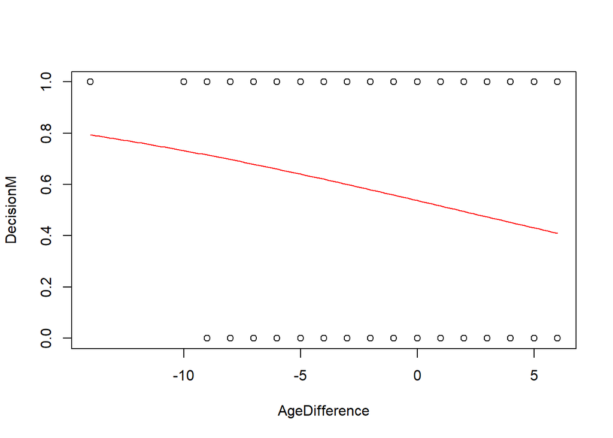

```r
logit = function(B0, B1, x)
  {
    exp(B0+B1*x)/(1+exp(B0+B1*x))
  }


B0 = summary(mod1)$coef[1]
B1 = summary(mod1)$coef[2]



plot(DecisionM~AgeDifference,data=SpeedDating)
curve(logit(B0, B1, x),add=TRUE, col="red")
```

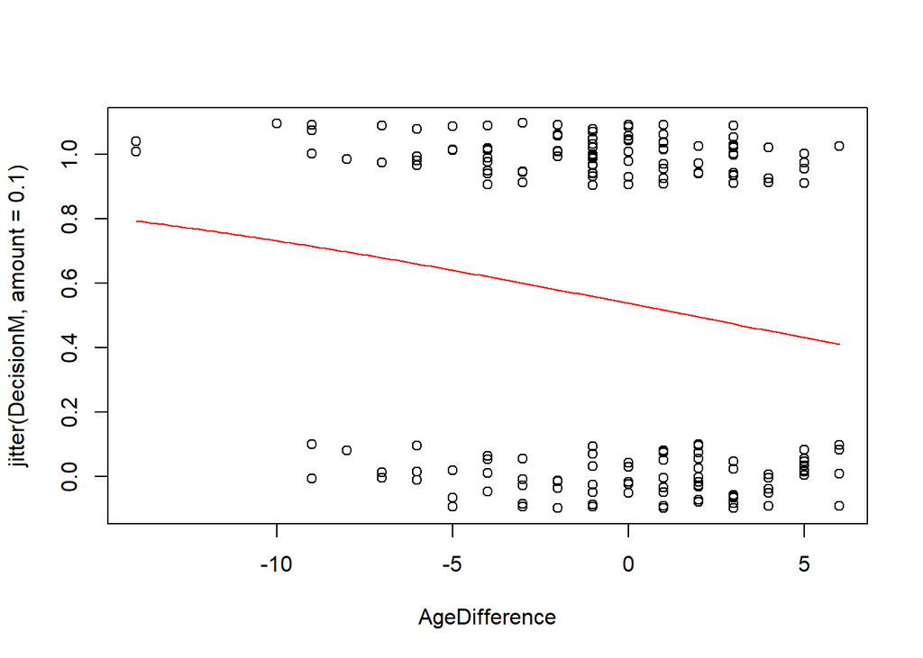

```r
plot(jitter(DecisionM, amount = 0.1)~AgeDifference,data=SpeedDating)
curve(logit(B0, B1, x),add=TRUE, col="red")
```

**Based on this plot, men have approximately a 50% chance of wanting to go on another date with a female when the age difference is right around 0 - when they are right around the same age.**

#3)

```r
exp(confint(mod1, level = 0.95))
```

```
##                   2.5 %    97.5 %
## (Intercept)   0.8610158 1.5698224
## AgeDifference 0.8464843 0.9910598
```

```r
(exp(confint(mod1, level = 0.95)))^5
```

```
##                   2.5 %   97.5 %
## (Intercept)   0.4732118 9.533506
## AgeDifference 0.4346048 0.956091
```

#4)

```r
mod2 <- glm(DecisionM~AgeDifference+RaceM+AgeDifference*RaceM, data = SpeedDating, family = "binomial")

anova(mod1, mod2, test = "Chisq")
```

|  | Resid. Df | Resid. Dev | Df | Deviance | Pr(>Chi) |
| --- | --- | --- | --- | --- | --- |
| 1 | 177 | 241.7162 | NA | NA | NA |
| 2 | 175 | 239.0196 | 2 | 2.696596 | 0.2596819 |

**The null hypothesis states that mod2 with the predictors “AgeDifference”, “RaceM”, and the interaction between the two is no more significant/effective when it comes to predicting “DecisionM” (The decision of the male) than mod1 with just AgeDifference as a predictor. The alternate hypothesis states that mod2 is more significant/effective than mod1 when it comes to predicting DecisionM. Because the p-value of the anova test is fairly high (greater than the alpha value 0.05), we accept the null hypothesis which suggests that mod2 is not more significant/effective than our first model mod1 for predicting whether or not the man would like another date (DecisionM).**

#5)

```r
head(SpeedDating)
```

| DecisionM | DecisionF | LikeM | LikeF | PartnerYesM | PartnerYesF | AgeM | AgeF | RaceM | RaceF | AttractiveM | AttractiveF | SincereM | SincereF | IntelligentM | IntelligentF | FunM | FunF | AmbitiousM | AmbitiousF | SharedInterestsM | SharedInterestsF | AgeDifference |
| --- | --- | --- | --- | --- | --- | --- | --- | --- | --- | --- | --- | --- | --- | --- | --- | --- | --- | --- | --- | --- | --- | --- |
| 0 | 0 | 6 | 7 | 5 | 5 | 27 | 21 | 3 | 3 | 6 | 5 | 8 | 8 | 8 | 8 | 8 | 2 | 7 | 2 | 6 | 2 | 6 |
| 1 | 0 | 8 | 7 | 4 | 3 | 22 | 22 | 3 | 1 | 7 | 6 | 9 | 6 | 10 | 8 | 6 | 4 | 6 | 9 | 5 | 4 | 0 |
| 1 | 0 | 10 | 6 | 10 | 2 | 22 | 23 | 1 | 1 | 10 | 4 | 10 | 7 | 10 | 9 | 10 | 4 | 10 | 3 | 10 | 2 | -1 |
| 1 | 1 | 9 | 7 | 7 | 8 | 23 | 24 | 3 | 3 | 9 | 7 | 9 | 9 | 9 | 7 | 9 | 6 | 9 | 5 | 9 | 7 | -1 |
| 1 | 1 | 7 | 5 | 8 | 5 | 24 | 26 | 4 | 5 | 7 | 5 | 9 | 10 | 8 | 8 | 9 | 8 | 7 | 5 | 7 | 5 | -2 |
| 0 | 0 | 7 | 6 | 7 | 6 | 27 | 23 | 3 | 3 | 6 | 5 | 7 | 9 | 8 | 9 | 6 | 5 | 6 | 9 | 5 | 7 | 4 |

```r
#SpeedDating.1 = within(SpeedDating,{DecisionF = NULL LikeM = NULL})
SpeedDating.1 = subset(SpeedDating, select = c(1,3,5,11,13,15,17,19,21,23))
head(SpeedDating.1)
```

| DecisionM | LikeM | PartnerYesM | AttractiveM | SincereM | IntelligentM | FunM | AmbitiousM | SharedInterestsM | AgeDifference |
| --- | --- | --- | --- | --- | --- | --- | --- | --- | --- |
| 0 | 6 | 5 | 6 | 8 | 8 | 8 | 7 | 6 | 6 |
| 1 | 8 | 4 | 7 | 9 | 10 | 6 | 6 | 5 | 0 |
| 1 | 10 | 10 | 10 | 10 | 10 | 10 | 10 | 10 | -1 |
| 1 | 9 | 7 | 9 | 9 | 9 | 9 | 9 | 9 | -1 |
| 1 | 7 | 8 | 7 | 9 | 8 | 9 | 7 | 7 | -2 |
| 0 | 7 | 7 | 6 | 7 | 8 | 6 | 6 | 5 | 4 |

```r
SpeedDatingReorder = SpeedDating.1[,c(2:10,1)] #with response last
SpeedDatingReorder2 <- data.frame(SpeedDatingReorder)
head(SpeedDatingReorder)
```

| LikeM | PartnerYesM | AttractiveM | SincereM | IntelligentM | FunM | AmbitiousM | SharedInterestsM | AgeDifference | DecisionM |
| --- | --- | --- | --- | --- | --- | --- | --- | --- | --- |
| 6 | 5 | 6 | 8 | 8 | 8 | 7 | 6 | 6 | 0 |
| 8 | 4 | 7 | 9 | 10 | 6 | 6 | 5 | 0 | 1 |
| 10 | 10 | 10 | 10 | 10 | 10 | 10 | 10 | -1 | 1 |
| 9 | 7 | 9 | 9 | 9 | 9 | 9 | 9 | -1 | 1 |
| 7 | 8 | 7 | 9 | 8 | 9 | 7 | 7 | -2 | 1 |
| 7 | 7 | 6 | 7 | 8 | 6 | 6 | 5 | 4 | 0 |

```r
bestglm(SpeedDatingReorder2, family=binomial)
```

```
## Morgan-Tatar search since family is non-gaussian.
```

```
## BIC
## BICq equivalent for q in (0.449473816939192, 0.808955819613877)
## Best Model:
##                 Estimate Std. Error   z value     Pr(>|z|)
## (Intercept)   -5.4561099 1.30992717 -4.165201 3.110785e-05
## LikeM          0.7059568 0.21172475  3.334314 8.551002e-04
## PartnerYesM    0.4081324 0.11794005  3.460508 5.391581e-04
## AttractiveM    0.8013503 0.19564111  4.096022 4.203098e-05
## SincereM      -0.5085140 0.18183531 -2.796564 5.164923e-03
## FunM          -0.3916697 0.17503202 -2.237703 2.524042e-02
## AgeDifference -0.1409521 0.05759791 -2.447174 1.439815e-02
```

```r
SpeedDatingReorder2.bestglm = bestglm(SpeedDatingReorder2, family=binomial)
```

```
## Morgan-Tatar search since family is non-gaussian.
```

```r
SpeedDatingReorder2.bestglm$BestModels
```

| LikeM | PartnerYesM | AttractiveM | SincereM | IntelligentM | FunM | AmbitiousM | SharedInterestsM | AgeDifference | Criterion |
| --- | --- | --- | --- | --- | --- | --- | --- | --- | --- |
| TRUE | TRUE | TRUE | TRUE | FALSE | TRUE | FALSE | FALSE | TRUE | 188.3059 |
| TRUE | TRUE | TRUE | TRUE | FALSE | FALSE | FALSE | FALSE | TRUE | 188.7115 |
| TRUE | TRUE | TRUE | TRUE | FALSE | TRUE | FALSE | FALSE | FALSE | 189.6210 |
| TRUE | TRUE | TRUE | TRUE | TRUE | FALSE | FALSE | FALSE | TRUE | 189.9023 |
| TRUE | TRUE | TRUE | TRUE | FALSE | FALSE | FALSE | FALSE | FALSE | 190.2315 |

**The model with the lowest BIC used the predictors LikeM, PartnerYesM, AttractiveM, SincereM, FunM, and AgeDifference. All five of the best models had very close BICs. IntelligentM, AmbitiousM, and SharedInterestsM were the variable missing from the top model. The first was included in one of the top five models, while the following two were included in none of the top five models**

```r
#model using predictors from bestglm result with the lowest BIC
SpeedDBestglm = glm(DecisionM~LikeM+PartnerYesM+AttractiveM+SincereM+FunM+AgeDifference, data = SpeedDatingReorder2, family = binomial)
```

```r
some_random_dude = data.frame(
  LikeM = 7,
  PartnerYesM = 7,
  AttractiveM = 7,
  SincereM = 7,
  FunM = 7,
  AgeDifference = 0
)

predict(SpeedDBestglm, some_random_dude)
```

```
##        1
## 1.650681
```

```r
odds = exp(predict(SpeedDBestglm, some_random_dude))

odds/(1+odds)
```

```
##         1
## 0.8389831
```

**This model predicts that there is approximately an 84% probabilty that the man would want to go on another date with a woman with the given specifications**

#6)

```r
head(SpeedDatingF)
```

| Like | PartnerYes | Attractive | Sincere | Intelligent | Fun | Ambitious | SharedInterests |
| --- | --- | --- | --- | --- | --- | --- | --- |
| 7 | 5 | 5 | 8 | 8 | 2 | 2 | 2 |
| 7 | 3 | 6 | 6 | 8 | 4 | 9 | 4 |
| 6 | 2 | 4 | 7 | 9 | 4 | 3 | 2 |
| 7 | 8 | 7 | 9 | 7 | 6 | 5 | 7 |
| 5 | 5 | 5 | 10 | 8 | 8 | 5 | 5 |
| 6 | 6 | 5 | 9 | 9 | 5 | 9 | 7 |

```r
#regsubsets

regsubsets2A=regsubsets(Like~., data=SpeedDatingF)
ShowSubsets(regsubsets2A)
```

|  | PartnerYes | Attractive | Sincere | Intelligent | Fun | Ambitious | SharedInterests | Rsq | adjRsq | Cp |
| --- | --- | --- | --- | --- | --- | --- | --- | --- | --- | --- |
| 1 ( 1 ) |  |  |  |  | * |  |  | 41.74 | 41.41 | 84.83 |
| 2 ( 1 ) |  | * |  |  |  |  | * | 51.79 | 51.24 | 42.03 |
| 3 ( 1 ) |  | * | * |  |  |  | * | 57.21 | 56.47 | 19.85 |
| 4 ( 1 ) |  | * |  | * | * |  | * | 60.57 | 59.66 | 6.86 |
| 5 ( 1 ) |  | * | * | * | * |  | * | 61.25 | 60.13 | 5.81 |
| 6 ( 1 ) | * | * | * | * | * |  | * | 61.62 | 60.28 | 6.18 |
| 7 ( 1 ) | * | * | * | * | * | * | * | 61.66 | 60.09 | 8.00 |

```r
#step

none = lm(Like~1, data=SpeedDatingF)
full = lm(Like~., data=SpeedDatingF)
MSE = (summary(full)$sigma)^2

step(none,scope=list(upper=full),scale=MSE, trace=0)
```

```
##
## Call:
## lm(formula = Like ~ Fun + SharedInterests + Attractive + Intelligent +
##     Sincere, data = SpeedDatingF)
##
## Coefficients:
##     (Intercept)              Fun  SharedInterests       Attractive
##        -0.01224          0.20114          0.23530          0.25198
##     Intelligent          Sincere
##         0.17276          0.11194
```

```r
#forward


step(none,scope=list(upper=full),scale=MSE, direction="forward", trace=0)
```

```
##
## Call:
## lm(formula = Like ~ Fun + SharedInterests + Attractive + Intelligent +
##     Sincere, data = SpeedDatingF)
##
## Coefficients:
##     (Intercept)              Fun  SharedInterests       Attractive
##        -0.01224          0.20114          0.23530          0.25198
##     Intelligent          Sincere
##         0.17276          0.11194
```

```r
#backward

step(full,scale=MSE, trace=0)
```

```
##
## Call:
## lm(formula = Like ~ Attractive + Sincere + Intelligent + Fun +
##     SharedInterests, data = SpeedDatingF)
##
## Coefficients:
##     (Intercept)       Attractive          Sincere      Intelligent
##        -0.01224          0.25198          0.11194          0.17276
##             Fun  SharedInterests
##         0.20114          0.23530
```

```r
#model for regsubsets

RegMod = lm(Like ~ SharedInterests + Fun + Intelligent + Sincere + Attractive, data = SpeedDatingF)

#model for step

StepMod = lm(Like ~ Fun + SharedInterests + Attractive + Intelligent +
    Sincere, data = SpeedDatingF)

#model for forward

ForwardMod = lm(Like ~ Fun + SharedInterests + Attractive + Intelligent +
    Sincere, data = SpeedDatingF)


#model for backward

BackwardMod = lm(Like ~ Attractive + Sincere + Intelligent + Fun +
    SharedInterests, data = SpeedDatingF)


#All four methods returned the same five predictors for the most effective model. The new model is listed below:

NewModF = lm(Like ~ Attractive + Sincere + Intelligent + Fun +
    SharedInterests, data = SpeedDatingF)

summary(NewModF)
```

```
##
## Call:
## lm(formula = Like ~ Attractive + Sincere + Intelligent + Fun +
##     SharedInterests, data = SpeedDatingF)
##
## Residuals:
##     Min      1Q  Median      3Q     Max
## -3.5716 -0.5210 -0.0250  0.6554  4.1326
##
## Coefficients:
##                 Estimate Std. Error t value Pr(>|t|)
## (Intercept)     -0.01224    0.49736  -0.025  0.98040
## Attractive       0.25198    0.05117   4.925 1.96e-06 ***
## Sincere          0.11194    0.06412   1.746  0.08260 .
## Intelligent      0.17276    0.07457   2.317  0.02170 *
## Fun              0.20114    0.05806   3.464  0.00067 ***
## SharedInterests  0.23530    0.04580   5.137 7.46e-07 ***
## ---
## Signif. codes:  0 '***' 0.001 '**' 0.01 '*' 0.05 '.' 0.1 ' ' 1
##
## Residual standard error: 1.116 on 173 degrees of freedom
## Multiple R-squared:  0.6125, Adjusted R-squared:  0.6013
## F-statistic:  54.7 on 5 and 173 DF,  p-value: < 2.2e-16
```

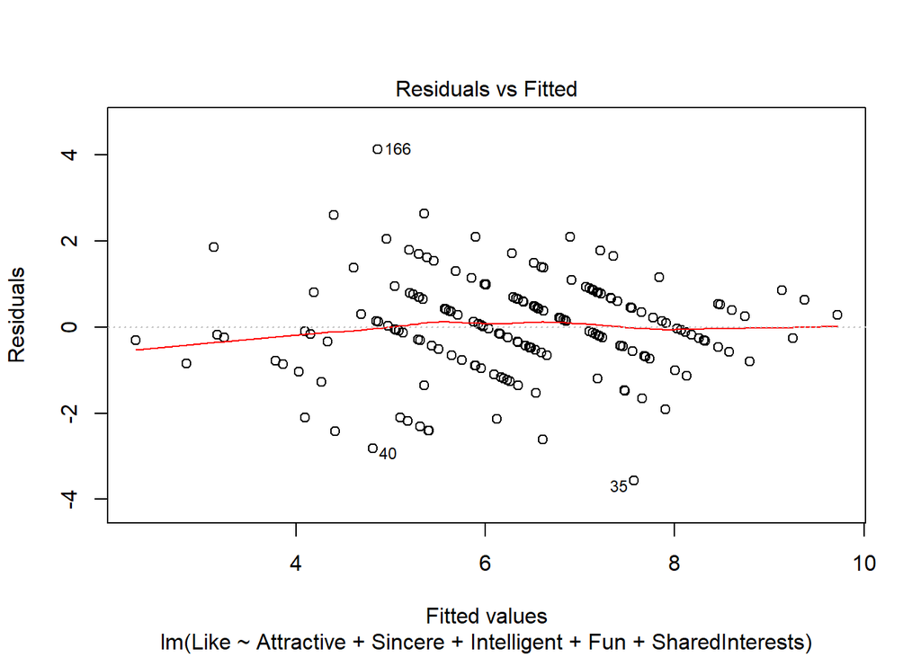

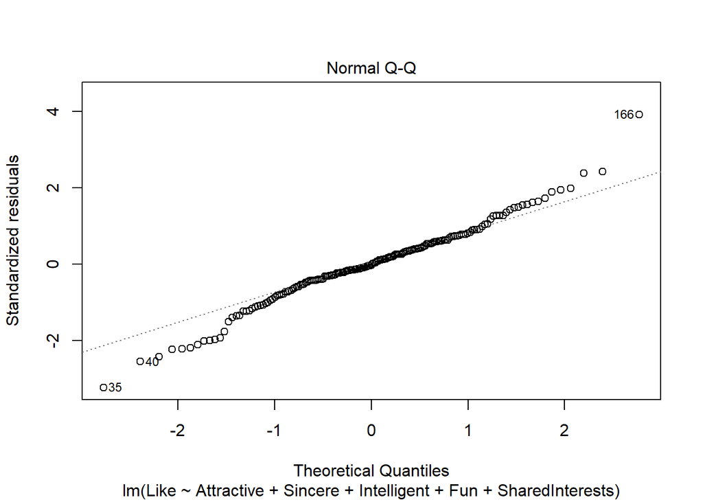

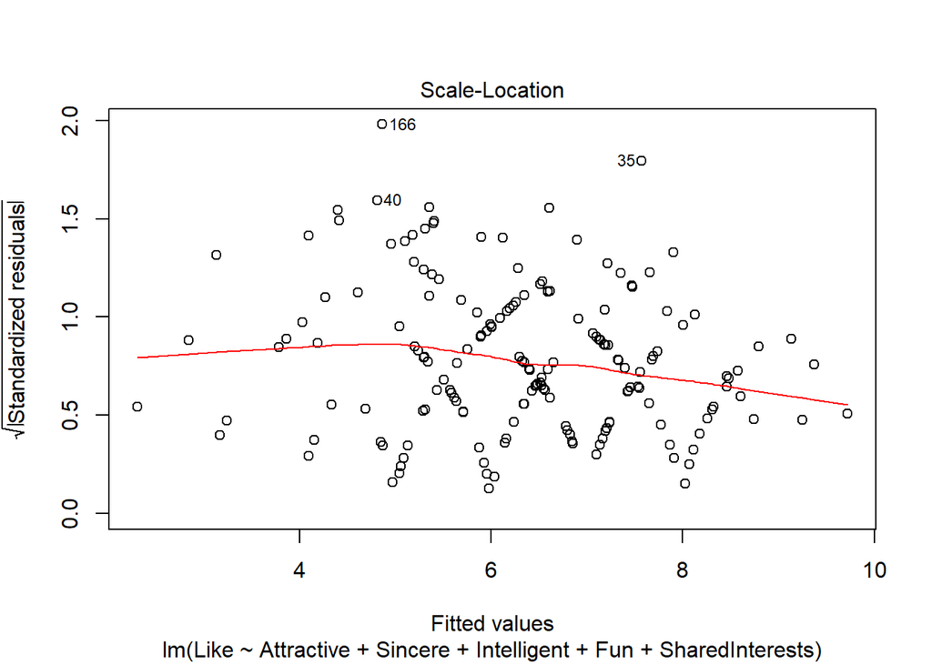

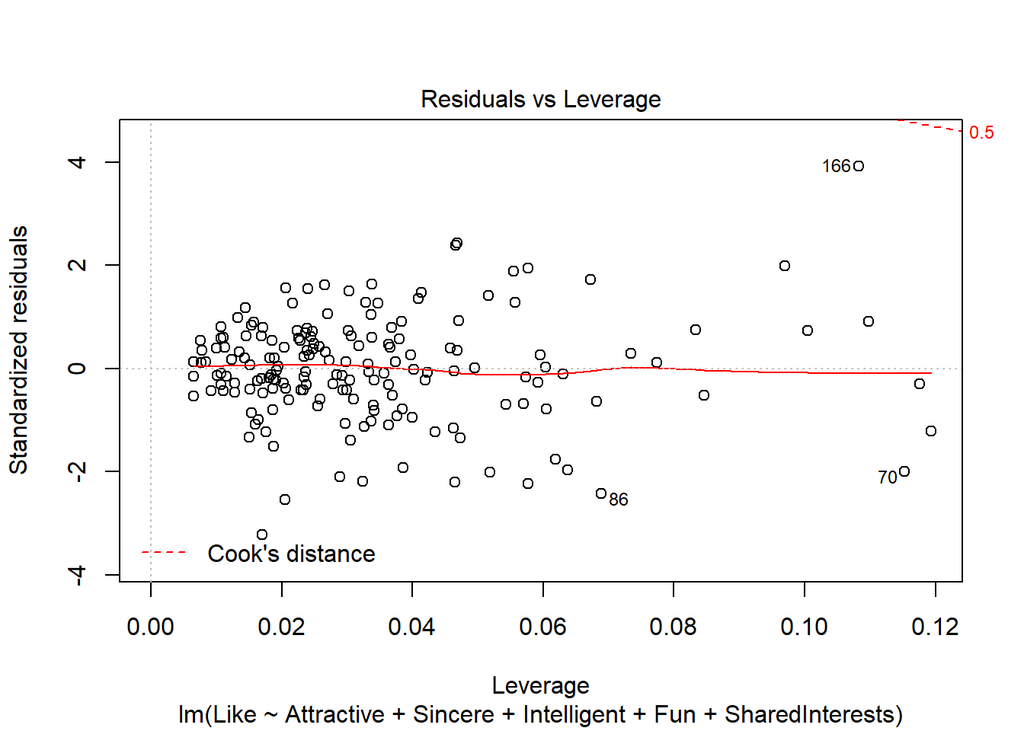

```r
plot(NewModF)
```

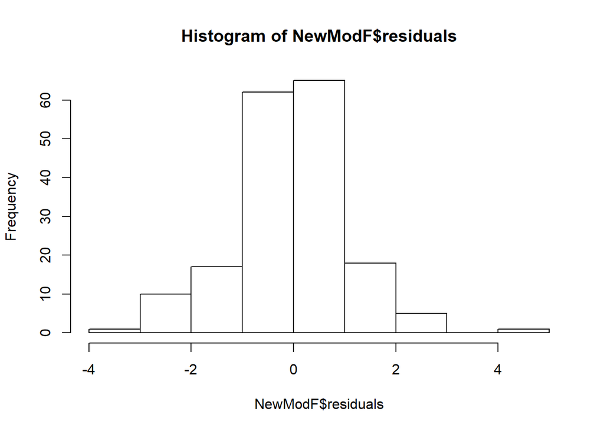

```r
hist(NewModF$residuals)
```

**The residuals vs. fitted plot appears mostly linear, with only a very slight curve to it. The constant variance condition does not seem to be satisfied because residuals are more varied on the left side of the graph. The zero mean condition appears satisfied, as residuals seem to be distributed evenly above and below the line. The normality of residuals condition is almost but not quite satisfied, as the histogram of residuals skews just slightly to the left and has an outlier on the far right side of the graph. The qqplot is also fairly linear with exception of the ends.**

#7)

```r
prediction = predict(NewModF, SpeedDatingM)

holdoutResid = SpeedDatingM$Like - prediction

mean(holdoutResid)
```

```
## [1] 0.08893696
```

```r
sd(holdoutResid)
```

```
## [1] 1.141413
```

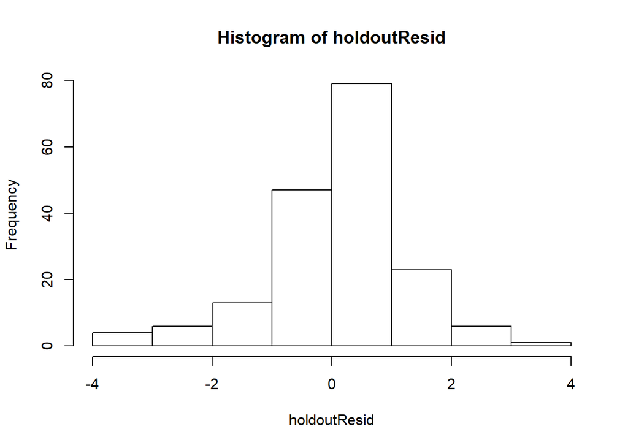

```r
hist(holdoutResid)
```

```r
summary(NewModF)
```

```
##
## Call:
## lm(formula = Like ~ Attractive + Sincere + Intelligent + Fun +
##     SharedInterests, data = SpeedDatingF)
##
## Residuals:
##     Min      1Q  Median      3Q     Max
## -3.5716 -0.5210 -0.0250  0.6554  4.1326
##
## Coefficients:
##                 Estimate Std. Error t value Pr(>|t|)
## (Intercept)     -0.01224    0.49736  -0.025  0.98040
## Attractive       0.25198    0.05117   4.925 1.96e-06 ***
## Sincere          0.11194    0.06412   1.746  0.08260 .
## Intelligent      0.17276    0.07457   2.317  0.02170 *
## Fun              0.20114    0.05806   3.464  0.00067 ***
## SharedInterests  0.23530    0.04580   5.137 7.46e-07 ***
## ---
## Signif. codes:  0 '***' 0.001 '**' 0.01 '*' 0.05 '.' 0.1 ' ' 1
##
## Residual standard error: 1.116 on 173 degrees of freedom
## Multiple R-squared:  0.6125, Adjusted R-squared:  0.6013
## F-statistic:  54.7 on 5 and 173 DF,  p-value: < 2.2e-16
```

```r
cvCorr = cor(prediction, SpeedDatingM$Like)
cvCorr
```

```
## [1] 0.7361731
```

```r
(cvCorr)^2
```

```
## [1] 0.5419508
```

```r
summary(NewModF)$r.squared - cvCorr^2
```

```
## [1] 0.07057265
```

**At approximatly 0.0889, the holdout residual mean is relatively close to zero. At approximately 1.1414, the holdout residual standard deviation is very close to the residual standard error from our original model.The holdout residual histogram has a normal distribution shape but has a fairly heavy left-skew to go along with it. The cross-validation correlation is approximately 0.736 - which means that the model does not predict the new data particularly well, however cvCorr squared is not that far off (as we see with the shrinkage) from the adjusted r^squared of the original model. Shrinkage is right around 0.07, which means that our model is about as good at predicting SpeedDatingM as the data it was designed for - SpeedDatingF, but could be better.**